# PCIT-CoS-Waitlist RCT Paper 1: CCQ Hostile Parenting, Controlling for ASD

Nancy Briggs

05 JAN 2021

### CCQ Hostile Parenting Adjusting for ASD

#### Descriptives

| asdcase | group | time | n | mean | sd | median | min | max |
| --- | --- | --- | --- | --- | --- | --- | --- | --- |
| 0 | 1 | 1 | 24 | 2.642 | 1.962 | 2.1 | 0.2 | 6.6 |
| 0 | 1 | 2 | 18 | 1.947 | 1.164 | 1.7 | 0.0 | 4.5 |
| 0 | 1 | 3 | 13 | 2.631 | 1.359 | 2.2 | 0.4 | 4.8 |
| 0 | 2 | 1 | 25 | 3.528 | 2.110 | 3.2 | 0.4 | 8.6 |
| 0 | 2 | 2 | 11 | 3.255 | 1.813 | 3.2 | 0.2 | 6.8 |
| 0 | 2 | 3 | 5 | 2.960 | 1.723 | 2.8 | 0.6 | 5.4 |
| 0 | 3 | 1 | 22 | 2.700 | 2.123 | 2.4 | 0.0 | 6.6 |
| 0 | 3 | 2 | 20 | 2.150 | 1.078 | 2.2 | 0.2 | 4.0 |
| 0 | 3 | 3 | 0 | NaN | NA | NA | Inf | -Inf |
| 1 | 1 | 1 | 6 | 2.733 | 3.061 | 1.8 | 0.2 | 8.8 |
| 1 | 1 | 2 | 5 | 2.440 | 3.015 | 2.0 | 0.0 | 7.6 |
| 1 | 1 | 3 | 5 | 3.280 | 3.895 | 2.4 | 0.0 | 10.0 |
| 1 | 2 | 1 | 3 | 1.933 | 1.514 | 2.6 | 0.2 | 3.0 |
| 1 | 2 | 2 | 2 | 3.000 | 4.243 | 3.0 | 0.0 | 6.0 |
| 1 | 2 | 3 | 0 | NaN | NA | NA | Inf | -Inf |
| 1 | 3 | 1 | 4 | 1.850 | 2.283 | 0.9 | 0.4 | 5.2 |
| 1 | 3 | 2 | 2 | 1.300 | 1.273 | 1.3 | 0.4 | 2.2 |
| 1 | 3 | 3 | 0 | NaN | NA | NA | Inf | -Inf |

[figure not shown]

#### Model & Results

A linear mixed model with random effect for individual and fixed effects of group, time and the interaction was run. ASD status was then entered into the model as a main effect and then the 3-way interaction. Estimated marginal means were obtained, and contrasts specified to test Hypothesis 1 and Hypothesis 2.

```
## fixed-effect model matrix is rank deficient so dropping 1 column / coefficient
```

```
## fixed-effect model matrix is rank deficient so dropping 3 columns / coefficients
```

```
## refitting model(s) with ML (instead of REML)
```

[output not shown]

Model3, the model with Group*Time, adjusted by ASD will be the model I use for Estimated Means.

```r
summary(result3)
```

```
## Linear mixed model fit by REML. t-tests use Satterthwaite's method [
## lmerModLmerTest]
## Formula: outcome ~ asdcase + group * time + (1 | id)
##    Data: dat
##
## REML criterion at convergence: 646.1
##
## Scaled residuals:
##     Min      1Q  Median      3Q     Max
## -1.7503 -0.5614 -0.1377  0.4016  2.4308
##
## Random effects:
##  Groups   Name        Variance Std.Dev.
##  id       (Intercept) 2.099    1.449
##  Residual             1.689    1.300
## Number of obs: 165, groups:  id, 85
##
## Fixed effects:
##               Estimate Std. Error        df t value Pr(>|t|)
## (Intercept)    2.73605    0.37078 114.03761   7.379 2.78e-11 ***
## asdcase1      -0.38024    0.52957  78.81496  -0.718    0.475
## group2         0.66184    0.51376 117.09668   1.288    0.200
## group3        -0.11957    0.52054 118.90025  -0.230    0.819
## time2         -0.53611    0.37234  84.21682  -1.440    0.154
## time3          0.20689    0.40805  86.03780   0.507    0.613
## group2:time2   0.08868    0.60621  91.56980   0.146    0.884
## group3:time2  -0.15245    0.53938  84.59159  -0.283    0.778
## group2:time3  -0.63466    0.82326  93.54532  -0.771    0.443
## ---
## Signif. codes:  0 '***' 0.001 '**' 0.01 '*' 0.05 '.' 0.1 ' ' 1
##
## Correlation of Fixed Effects:
##             (Intr) asdcs1 group2 group3 time2  time3  grp2:2 grp3:2
## asdcase1    -0.286
## group2      -0.690  0.096
## group3      -0.668  0.050  0.477
## time2       -0.405 -0.009  0.293  0.290
## time3       -0.363 -0.030  0.266  0.264  0.419
## group2:tim2  0.254 -0.013 -0.376 -0.179 -0.614 -0.257
## group3:tim2  0.272  0.034 -0.200 -0.437 -0.691 -0.290  0.424
## group2:tim3  0.176  0.030 -0.273 -0.130 -0.208 -0.496  0.325  0.144
## fit warnings:
## fixed-effect model matrix is rank deficient so dropping 1 column / coefficient
```

#### Estimated Means & Change

Estimated means for each Treatment and Time (adjusted by ASD status) are presented. In addition, within-group change between time points is presented with 95% CIs.

##### Group mean difference at each timepoint

Effect sizes all calculated by the pooled T1 SD of the outcome. Adjusted p-value from Bonferroni correction.

Group Differences at Each Time Point

| Group Difference | Time | Mean | SE | t | p | adj p | Lower CL | Upper CL | Effect Size | Lower CL | Upper CL |
| --- | --- | --- | --- | --- | --- | --- | --- | --- | --- | --- | --- |
| 1 - 2 | 1 | -0.662 | 0.514 | -1.288 | 0.405 | 0.601 | -1.882 | 0.558 | -0.311 | -0.917 | 0.174 |
| 1 - 3 | 1 | 0.120 | 0.521 | 0.230 | 0.971 | 1.000 | -1.116 | 1.355 | 0.056 | -0.482 | 0.580 |
| 2 - 3 | 1 | 0.781 | 0.529 | 1.477 | 0.306 | 0.427 | -0.474 | 2.037 | 0.367 | -0.109 | 1.008 |
| 1 - 2 | 2 | -0.751 | 0.632 | -1.187 | 0.463 | 0.712 | -2.248 | 0.747 | -0.353 | -1.017 | 0.281 |
| 1 - 3 | 2 | 0.272 | 0.564 | 0.483 | 0.880 | 1.000 | -1.064 | 1.608 | 0.128 | -0.480 | 0.722 |
| 2 - 3 | 2 | 1.023 | 0.639 | 1.600 | 0.249 | 0.335 | -0.490 | 2.535 | 0.480 | -0.155 | 1.145 |
| 1 - 2 | 3 | -0.027 | 0.847 | -0.032 | 0.999 | 1.000 | -2.032 | 1.978 | -0.013 | -0.826 | 0.800 |
| 1 - 3 | 3 | NA | NA | NA | NA | NA | NA | NA | NA | NA | NA |
| 2 - 3 | 3 | NA | NA | NA | NA | NA | NA | NA | NA | NA | NA |

* Effect size scaled by pooled T1 SD  
† ES 95% Bootstrapped Percentile CI limits  
‡ If you want a positive ES (and it is calculated as negative), be sure to switch the signs and positions of the lower and upper CIs.

##### Change within each group

Within-Group Change and Effect Sizes

| Change | Group | Mean | SE | t | p | adj p | Lower CL | Upper CL | Effect Size | Lower CL | Upper CL |
| --- | --- | --- | --- | --- | --- | --- | --- | --- | --- | --- | --- |
| 1 - 2 | 1 | 0.536 | 0.373 | 1.437 | 0.327 | 0.463 | -0.354 | 1.426 | 0.252 | -0.101 | 0.670 |
| 1 - 3 | 1 | -0.207 | 0.409 | -0.506 | 0.869 | 1.000 | -1.183 | 0.769 | -0.097 | -0.518 | 0.259 |
| 2 - 3 | 1 | -0.743 | 0.422 | -1.759 | 0.190 | 0.247 | -1.751 | 0.265 | -0.349 | -0.854 | 0.040 |
| 1 - 2 | 2 | 0.447 | 0.481 | 0.931 | 0.622 | 1.000 | -0.697 | 1.592 | 0.210 | -0.205 | 0.753 |
| 1 - 3 | 2 | 0.428 | 0.718 | 0.595 | 0.823 | 1.000 | -1.283 | 2.139 | 0.201 | -0.489 | 0.914 |
| 2 - 3 | 2 | -0.020 | 0.739 | -0.027 | 1.000 | 1.000 | -1.781 | 1.742 | -0.009 | -0.771 | 0.705 |
| 1 - 2 | 3 | 0.689 | 0.391 | 1.762 | 0.189 | 0.245 | -0.244 | 1.621 | 0.323 | -0.032 | 0.773 |
| 1 - 3 | 3 | NA | NA | NA | NA | NA | NA | NA | NA | NA | NA |
| 2 - 3 | 3 | NA | NA | NA | NA | NA | NA | NA | NA | NA | NA |

* Effect size scaled by pooled T1 SD  
† ES 95% Bootstrapped Percentile CI limits  
‡ If you want a positive ES (and it is calculated as negative), be sure to switch the signs and positions of the lower and upper CIs.

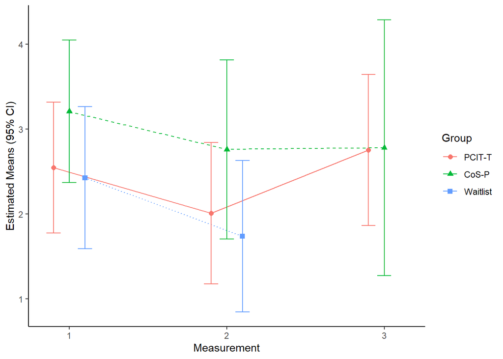

#### Hypothesis 1

We hypothesize that from baseline (‘T1’) to post-treatment/waitlist (‘T2’) there will be a gradient effect, whereby parent-child dyads who receive PCIT-T will show the greatest gains and parent-child dyads who receive no treatment will show the least gains. For the outcome, then, the null hypothesis is:

$H_0: \text {mean change}(\text{PCIT-T}) = \text {mean change}(\text{CoS-P}) = \text {mean change}(\text{Waitlist})$ $H_A: \text {mean change}(\text{PCIT-T}) > \text {mean change}(\text{CoS-P}) > \text {mean change}(\text{Waitlist})$

This is a joint hypothesis test.

First, confirming that the ordering of the means is as hypothesized:

```
## group = 1:
##  contrast estimate    SE   df t.ratio p.value
##  1 - 2      0.5361 0.373 82.8   1.437  0.3266
##  1 - 3     -0.2069 0.409 84.6  -0.506  0.8687
##  2 - 3     -0.7430 0.422 80.4  -1.759  0.1899
##
## group = 2:
##  contrast estimate    SE   df t.ratio p.value
##  1 - 2      0.4474 0.481 94.8   0.931  0.6221
##  1 - 3      0.4278 0.718 94.8   0.595  0.8229
##  2 - 3     -0.0196 0.739 85.5  -0.027  0.9996
##
## group = 3:
##  contrast estimate    SE   df t.ratio p.value
##  1 - 2      0.6886 0.391 83.5   1.762  0.1888
##  1 - 3      nonEst    NA   NA      NA      NA
##  2 - 3      nonEst    NA   NA      NA      NA
##
## Results are averaged over the levels of: asdcase
## Degrees-of-freedom method: kenward-roger
## P value adjustment: tukey method for comparing a family of 3 estimates
```

The ordering is not as expected.

Now, to get the p-value associated with the joint hypothesis.

```
##   (Intercept) asdcase1 group2 group3 time2 time3 group2:time2 group3:time2
## 1           0        0      0      0     0     0           -1            0
## 2           0        0      0      0     0     1            0            1
##   group2:time3
## 1            0
## 2            0
```

```
##
##   General Linear Hypotheses
##
## Linear Hypotheses:
##        Estimate
## 1 == 0 -0.08868
## 2 == 0  0.05443
##
## Global Test:
##        F DF1 DF2 Pr(>F)
## 1 0.0128   2 154 0.9873
```

p>0.05, so this joint null hypothesis is not rejected.

#### Hypothesis 2

There will be a gradient of size of change from T2 to T3 such that the change in the PCIT-T group > the change in the CoS-P group. This isn’t really a gradient; it’s just 1 hypothesis.

First, the change in PCITT and COSP from time 2 to time 3:

```
## group = 1:
##  contrast estimate    SE   df t.ratio p.value
##  1 - 2      0.5361 0.373 82.8   1.437  0.3266
##  1 - 3     -0.2069 0.409 84.6  -0.506  0.8687
##  2 - 3     -0.7430 0.422 80.4  -1.759  0.1899
##
## group = 2:
##  contrast estimate    SE   df t.ratio p.value
##  1 - 2      0.4474 0.481 94.8   0.931  0.6221
##  1 - 3      0.4278 0.718 94.8   0.595  0.8229
##  2 - 3     -0.0196 0.739 85.5  -0.027  0.9996
##
## group = 3:
##  contrast estimate    SE   df t.ratio p.value
##  1 - 2      0.6886 0.391 83.5   1.762  0.1888
##  1 - 3      nonEst    NA   NA      NA      NA
##  2 - 3      nonEst    NA   NA      NA      NA
##
## Results are averaged over the levels of: asdcase
## Degrees-of-freedom method: kenward-roger
## P value adjustment: tukey method for comparing a family of 3 estimates
```

```
##
##   Simultaneous Tests for General Linear Hypotheses
##
## Fit: lmer(formula = outcome ~ asdcase + group * time + (1 | id), data = dat)
##
## Linear Hypotheses:
##        Estimate Std. Error z value Pr(>|z|)
## 1 == 0  -0.7233     0.8489  -0.852    0.394
## (Adjusted p values reported -- single-step method)
```

p>0.05.

#### Residuals

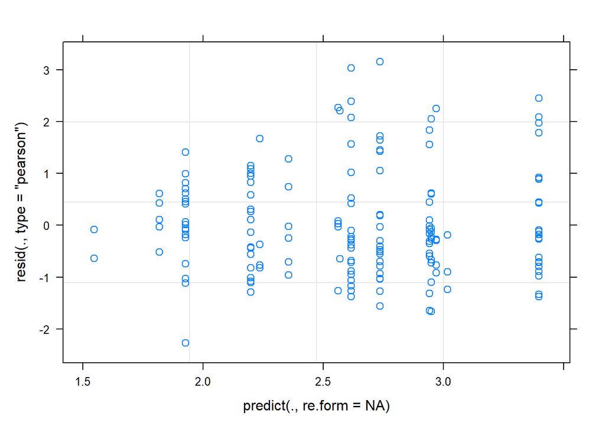

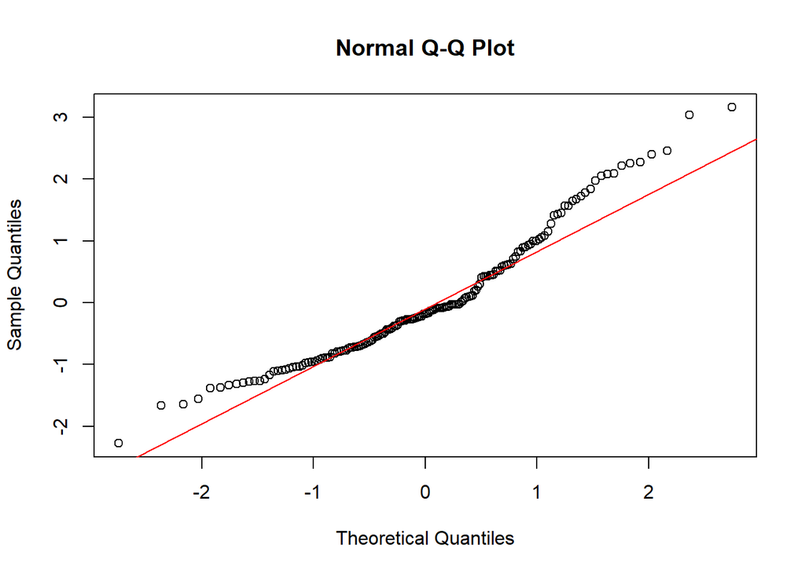

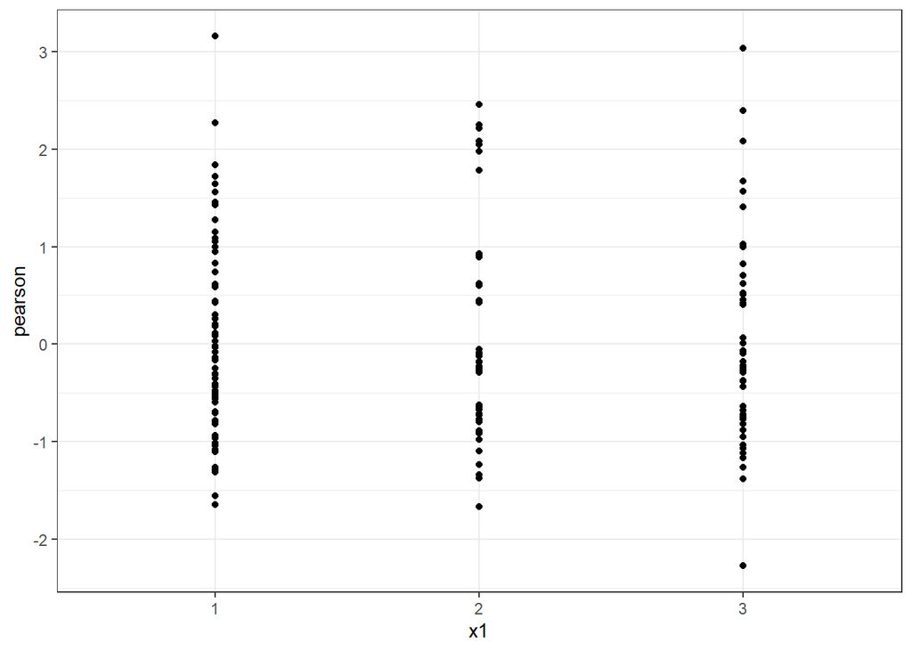

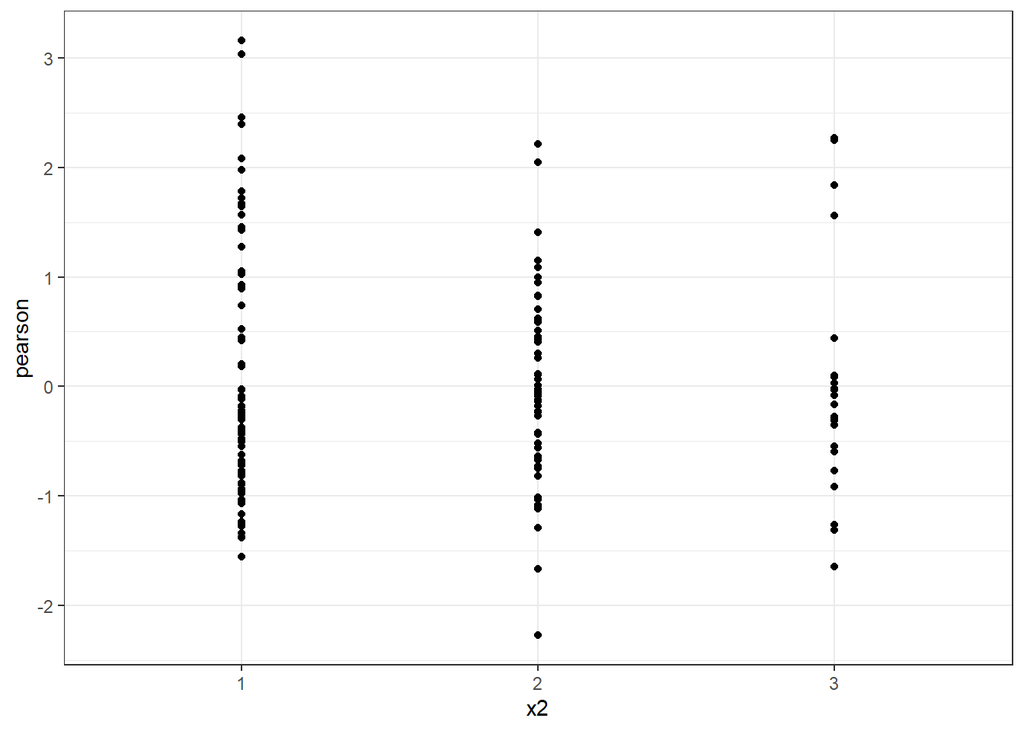

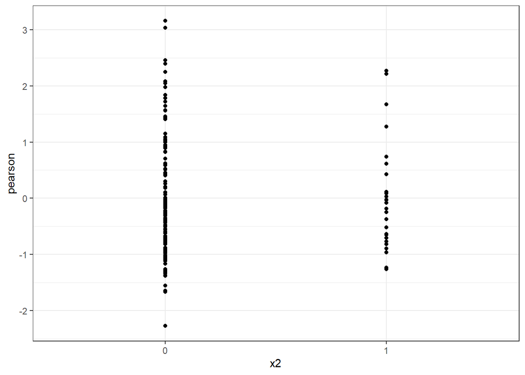

```r
rm(list = ls())
```